# Aproximación Socioecológica: Percepción de las interacciones entre el lobo fino de Juan Fernández y la comunidad Isleña

### **Introducción**

Adicionalmente a las estimaciones de abundancia, nos propusimos estudiar la relación entre las comunidades humanas y el Lobo Fino de Juan Fernandez (en adelante, el lobo fino). Particularmente, cómo percibe la comunidad a la especie y cómo el lobo fino interactúa con la pesca artesanal.

**¿Por qué creímos necesaria una investigación de estas características?** El importante crecimiento de la población de lobo fino permitía imaginar un aumento en las interacciones entre la especie y las comunidades humanas, lo que podría derivar en un potencial conflicto. Más aún si se considera que la pesca artesanal es la principal actividad económica de Juan Fernández y que existen muchos ejemplos de interacción negativa entre mamíferos marinos y la pesca en otros lugares del país y del mundo.

### **Metodología**

Se aplicaron entrevistas y encuestas en islas Robinson Crusoe y Alejandro Selkirk con múltiples preguntas en torno a la interacción del humano y los lobos finos. El universo de encuestados y entrevistados contempló hombres y mujeres mayores de edad, pescadores y no pescadores. Se aplicaron 302 encuestas, (según ocupación, 29% pescadores y 71% no pescadores) y 21 entrevistas (según ocupación, 38% pescadores y 62% no pescadores) .

A la comunidad en general se le aplicó una encuesta que medía sus percepciones sobre el lobo y a los pescadores se les aplicó además una segunda parte de la encuesta referente a las percepciones sobre la interacción de la especie con la pesca.

### **Resultados**

#### **Percepciones y actitudes (pescadores y no pescadores)**

La primera parte de la encuesta constaba con una serie de afirmaciones sobre las que pescadores y no pescadores debían manifestar su grado de acuerdo. Las afirmaciones sobre un mismo tema fueron agrupadas en indicadores. Estos indicadores podían tener valores entre -1 y 1, donde mientras más cercano al -1, más negativa era la percepción, mientras que, mientras más cercana al +1 más positiva era la percepción.

Tabla 1. Valor promedio de los indicadores de actitudes de las y los encuestados sobre el LFJF

| Indicador | X̅ |
| --- | --- |
| Si el lobo genera o no simpatía | 0.90 |
| Si cree que la comunidad en general comparte una opinión positiva en torno al lobo | 0.90 |
| Si cree que de hacerle daño al lobo serán sancionados | 0.28 |
| Si les parece que la regulación y las referentes al lobo son legítimas | 0.57 |
| Si creen que el lobo puede tener un impacto sobre la pesca y así, sobre el bolsillo | 0.58 |
| Si se considera el valor valor ecosistémico de la especie | 0.77 |
| Si el lobo afecta o no su vida cotidiana | 0.35 |

Se plantearon dos preguntas que indagan en la interacción actual y futura con la especie: *“Hoy, los lobos alteran el día a día de los habitantes de Juan Fernández”*, un 85% está en desacuerdo con la afirmación y tan sólo un 6,6% está de acuerdo. Ahora bien, las respuestas cambian radicalmente si se plantea la misma pregunta pero respecto al futuro: *“En el futuro los lobos podrían alterar el día a día de los habitantes de Juan Fernández”*, ante la que un 47,4% de los encuestados está de acuerdo, mientras el desacuerdo es 40,7%.

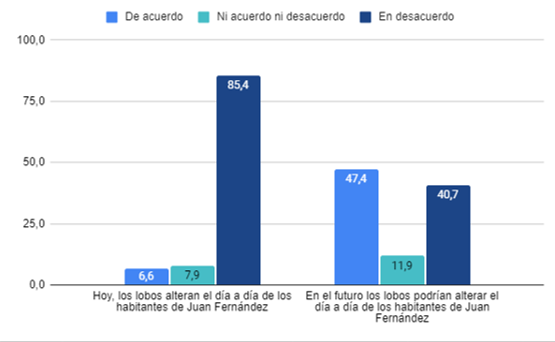

Figura 1. Grado de acuerdo con “Hoy, los lobos alteran el día a día de los habitantes de Juan Fernández” y “En el futuro los lobos podrían alterar el día a día de los habitantes de Juan Fernández”. En las entrevistas, al igual que en las encuestas se advierte que, si bien existe una apreciación positiva de la especie, existe preocupación sobre los impactos que puede tener el aumento de la población del lobo.

#### **Percepciones de la interacción entre el LFJF y la Pesca Artesanal (sólo pescadores)**

Se planteó *“Si entendemos la interferencia entre los Lobos y la pesca como dificultar las actividades pesqueras, ¿el lobo fino interfiere en la pesca?”*. Un 65% de los pescadores encuestados señala que nunca hay interacción negativa entre el lobo y la pesca y un 34% señala que a veces hay interacción negativa.

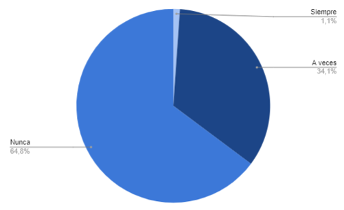

Figura 2. Frecuencia de la interferencia del lobo hacia la pesca artesanal según pescadores

En las encuestas y entrevistas, pescadores describieron cómo ocurre la interacción con la especie (estas son frases propias de los pescadores):

- A veces, el lobo saca pescados del anzuelo (especialmente el jurelillo y que esto ocurre con más frecuencia si se deja espinel extendido durante la noche).
- A veces, el lobo “pica” (es decir, se quedan capturados en el anzuelo) cuando se deja el espinel extendido durante la noche, más aún si lleva pulpo (octopus crusoe) o jibia (Dosidicus gigas) como carnada.
- A veces, el LFJF se enreda en el baticulo (cordel) de las trampas. Así, se pierde material.
- La presencia de grandes poblaciones de lobo altera el sabor de las especies de roca que allí se encuentran, incluyendo la Langosta, la corvina y la jerguilla.
- A veces, el lobo puede atacar a los buzos apnea, particularmente cuando están capturando pulpo. Se trata de ataques de poca gravedad y que no ocasionan heridas.

Es interesante notar que a lo largo del trabajo de campo también se mencionó la preocupación sobre la transformación en los hábitos del lobo: el consumo de especies que antes no comían (jurel) y estar acostumbrándose a ser alimentado. Aunque no encontramos evidencia que sugiera que el lobo se alimenta de especies del archipiélago, tampoco sabemos cuán flexible puede ser su dieta y cómo podría cambiar en el futuro. Por lo mismo, **ES SUMAMENTE IMPORTANTE NO ALIMENTAR A LOS LOBOS**! ya que puede repercutir en el aumento de interacciones en el futuro como se ha visto en especies similares en el continente que hoy afectan el día a día de la comunidad.

Sobre las proyecciones en torno a la interacción de la pesca con la especie se preguntó: *“En el futuro, ¿Cree usted que la interferencia entre el Lobo fino y la pesca se va a mantener estable, va a aumentar o va a disminuir?”*, ante lo cual, un 61,6% de los encuestados señaló que va a aumentar, un 37,2% que se va a mantener estable y sólo un 1,2% que va a disminuir.

Ante la pregunta *“¿Le ha pasado que el Lobo coma o intente comer lo que ustedes pescan?”* (o sea, si el LFJF extrae recursos del arte), un 72% de los encuestados señala que sí le ha pasado, mientras que un 28% dice que no le ha pasado.

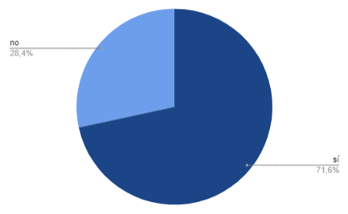

Figura 3. Pescadores que declaran que el Lobo ha comido o intentado comer lo pescado

De acuerdo a los encuestados, que el LFJF coma o intente comer lo que han pescado, les ha ocurrido más frecuentemente al pescar jurel o jurelillo. Cabe aclarar que esos episodios **no son muy frecuentes**. Dentro del 71,6% de pescadores a quienes les ha ocurrido, a un 44,8% de ellos les ha ocurrido sólo una o algunas veces a lo largo de toda su vida como pescador, mientras que un 36.2% señala que estos episodios sólo ocurren entre 1 y 10 veces en el año y sólo un 5,2% señala que ocurre una o más veces en la semana.

Un 52% de los pescadores señaló conocer uno o más episodios de captura accidental de lobo (o sea, de pesca incidental y enredamientos). Esos accidentes no necesariamente tienen resultado de muerte. En muchas ocasiones, según describieron los pescadores, el animal logra liberarse o en otras, son ellos quienes rescataron a los animales enredados.

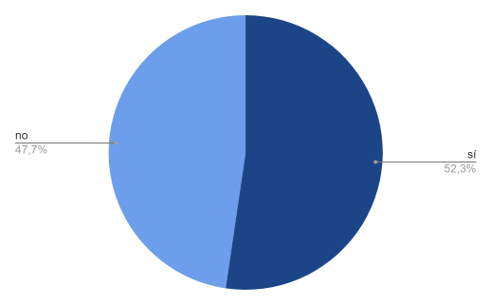

Figura 4. Pescadores que señalan conocer uno o más episodios de captura accidental del Lobo en las faenas de pesca artesanal

Aquellos pescadores que en las encuestas o a lo largo de la observación etnográfica señalan que sí han debido cambiar alguna de sus prácticas para evitar la interferencia:

- Cambiar la forma de disponer los cordeles de las trampas para evitar que los lobos se enreden.
- Dejar de ir a pescar a sitios donde hay mayor interacción
- Dejar de disponer los espineles extendidos toda la noche

Los hallazgos dan cuenta que la interacción entre el LFJF y la pesca artesanal del Archipiélago de Juan Fernández no es percibida como un problema por parte de los pescadores artesanales.

Se plantearon dos preguntas dirigidas a los pescadores acerca del impacto de la creación del AMCP-MU sobre la biomasa: *“En su opinión, desde la creación del Área Marina Protegida Costera de Múltiples Usos, ¿Siente que la disponibilidad de peces/crustáceos se ha mantenido estable, ha aumentado o ha disminuido?”*.

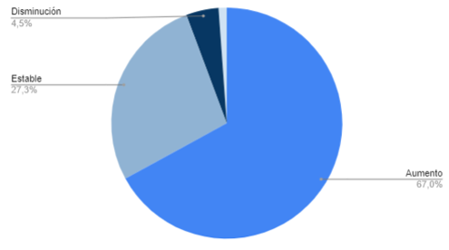

Figura 5. Percepciones acerca de la variación en la disponibilidad de peces desde la creación del Área Marina Protegida Costera de Múltiples Usos

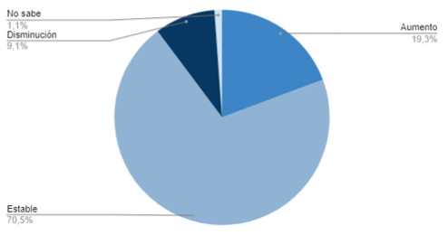

Figura 6. Percepciones acerca de la variación en la disponibilidad de crustáceos desde la creación del Área Marina Protegida Costera de Múltiples Usos

En opinión de los pescadores, a partir de la creación del AMCP-MU ha habido un aumento en la disponibilidad de peces. No así en el caso de los crustáceos, donde el 70% de los pescadores encuestados señala que se ha mantenido estable la disponibilidad.

#### Anexo 1. Valor promedio de los indicadores de actitudes de las y los encuestados sobre el LFJF

| Indicador | X̅ |
| --- | --- |
| Apreciación de la especie | 0.90 |
| Norma social | 0.90 |
| Probabilidad de sanción | 0.28 |
| Legitimidad de la regulación | 0.57 |
| Motivaciones económicas | 0.58 |
| Reconocimiento del rol ecosistémico de la especie | 0.77 |
| Conflicto Vida cotidiana | 0.35 |